# Transfer Portal Grading (Offensive Skill Positions Only)

Micah Copple

2026-04-02

```r
usethis::edit_r_environ()
```

```
## ☐ Edit '/Users/micahcopple/.Renviron'.
```

```
## ☐ Restart R for changes to take effect.
```

```r
player_stats <- cfbd_stats_season_player(year = 2025)
```

```r
transfer <- read.csv("download.csv")
```

Now we can clean the transfer and stats data. I’ll create position groups to make joining easier and cleaner

```r
set.seed(2829)

position_group <- function(pos) {
  case_when(
    pos %in% c("EDGE", "LB", "DL",
               "DT", "NT", "DE")             ~ "front_seven",
    pos %in% c("S", "CB", "DB")              ~ "defensive_back",
    pos %in% c("OT", "IOL", "OL", "C", "G") ~ "offensive_line",
    pos %in% c("K", "P", "PK")              ~ "specialist",
    TRUE                                     ~ pos
  )
}
```

Now we actually clean the transfer data

```r
transfer <- transfer %>%
  mutate(

    #combine first and last name

    full_name = str_trim(paste(FirstName, LastName, sep = " ")),

    #fix team name mismatches between portal and player_stats

    Origin = case_when(
        Origin == "Albany"                  ~ "UAlbany",
        Origin == "Saint Francis (PA)"      ~ "St. Francis (PA)",
        Origin == "Southeastern Louisiana"  ~ "SE Louisiana",
        Origin == "Texas-Rio Grande Valley" ~ "UT Rio Grande Valley",
        Origin == "St. Thomas"              ~ "St. Thomas (MN)",
        Origin == "LIU Post"                ~ "Long Island University",
        Origin == "San José State"          ~ "San Jose State",  # encoding fix
        TRUE                                ~ Origin
),

    #apply position groups
    pos_group = position_group(Position)
  )
```

Now we do the same for player_stats

```r
player_stats <- player_stats %>%
  mutate(

    #standardize position names to match transfer portal

    position = case_when(
      position %in% c("DE", "NT", "DT") ~ "DL",
      position %in% c("C", "G", "OL")   ~ "IOL",
      position == "DB"                   ~ "CB",
      position == "PK"                   ~ "K",
      position == "FB"                   ~ "RB",
      position == "KR"                   ~ "ATH",
      TRUE                               ~ position
    ),

    #apply position groups
    pos_group = position_group(position)
  )
```

Now we can join on name, team, and position group

```r
transfer_stats <- transfer %>%
  inner_join(player_stats,
             by = c("full_name" = "player",
                    "Origin"    = "team",
                    "pos_group"))
```

```r
transfer_stats <- transfer_stats %>%
  mutate(scoring_position = Position)
```

```r
cat("Total portal players:  ", nrow(transfer), "\n")
```

```
## Total portal players:   4406
```

```r
cat("Successfully joined:   ", nrow(transfer_stats), "\n")
```

```
## Successfully joined:    2441
```

```r
cat("Recovery rate:         ",
    round(nrow(transfer_stats) / nrow(transfer) * 100, 1), "%\n")
```

```
## Recovery rate:          55.4 %
```

2441 isn’t bad considering the multiple errors in the data. We can start doing exploratory analysis to understand the data

How many players per position?

```r
transfer_stats %>%
  count(scoring_position) %>%
  arrange(desc(n))
```

```
##    scoring_position   n
## 1                WR 382
## 2                CB 307
## 3                 S 283
## 4                DL 260
## 5              EDGE 258
## 6                LB 257
## 7                RB 231
## 8                QB 176
## 9                TE 130
## 10                K  54
## 11                P  39
## 12               OT  28
## 13              IOL  24
## 14               LS  12
```

Distribution of stars

```r
transfer_stats %>%
  count(Stars) %>%
  arrange(desc(Stars))
```

```
##   Stars    n
## 1     5    8
## 2     4  185
## 3     3 1810
## 4     2   69
## 5    NA  369
```

Which conferences are losing the most players?

```r
transfer_stats %>%
  count(conference) %>%
  arrange(desc(n))
```

```
##           conference   n
## 1             Big 12 265
## 2                SEC 256
## 3            Big Ten 248
## 4                ACC 239
## 5           Sun Belt 227
## 6  American Athletic 212
## 7       Mid-American 167
## 8     Conference USA 133
## 9      Mountain West 110
## 10           Big Sky  67
## 11               CAA  64
## 12          Southern  53
## 13            Pac-12  49
## 14               UAC  42
## 15     Big South-OVC  41
## 16         Southland  40
## 17           Patriot  37
## 18              MVFC  36
## 19  FBS Independents  35
## 20              SWAC  35
## 21               Ivy  25
## 22              MEAC  20
## 23               NEC  20
## 24           Pioneer  16
## 25  FCS Independents   3
## 26              SIAC   1
```

Which teams are losing the most players?

```r
transfer_stats %>%
  count(Origin) %>%
  arrange(desc(n)) %>%
  head(20)
```

```
##              Origin  n
## 1        Iowa State 32
## 2    Oklahoma State 32
## 3     Florida State 31
## 4          Arkansas 28
## 5        Penn State 28
## 6     Georgia State 27
## 7  Coastal Carolina 26
## 8       North Texas 26
## 9     West Virginia 26
## 10   Colorado State 25
## 11              UCF 25
## 12 Washington State 25
## 13        App State 24
## 14     Oregon State 24
## 15           Toledo 24
## 16            UConn 24
## 17   Michigan State 23
## 18    South Florida 23
## 19          Memphis 22
## 20           Auburn 21
```

Top destinations

```r
transfer_stats %>%
  count(Destination) %>%
  arrange(desc(n)) %>%
  head(20)
```

```
##         Destination   n
## 1                   502
## 2    Oklahoma State  36
## 3             UConn  32
## 4          Colorado  30
## 5        Iowa State  30
## 6           Memphis  29
## 7          Arkansas  28
## 8       North Texas  28
## 9     South Florida  27
## 10       Penn State  26
## 11             UCLA  26
## 12           Auburn  25
## 13       California  25
## 14        Wisconsin  25
## 15              LSU  23
## 16       Louisville  23
## 17           Kansas  22
## 18         Virginia  22
## 19 Coastal Carolina  21
## 20           Purdue  21
```

Rating distributions by position

```r
transfer_stats %>%
  filter(!is.na(Rating)) %>%
  group_by(scoring_position) %>%
  summarise(
    avg_rating = mean(Rating, na.rm = TRUE),
    avg_stars  = mean(Stars, na.rm = TRUE),
    n          = n()
  ) %>%
  arrange(desc(avg_rating))
```

```
## # A tibble: 14 × 4
##    scoring_position avg_rating avg_stars     n
##    <chr>                 <dbl>     <dbl> <int>
##  1 OT                    0.88       3.26    19
##  2 WR                    0.865      3.16   238
##  3 EDGE                  0.863      3.13   181
##  4 QB                    0.862      3.16   116
##  5 DL                    0.862      3.10   164
##  6 TE                    0.860      3.09    93
##  7 RB                    0.856      3.04   156
##  8 CB                    0.856      3.05   184
##  9 S                     0.856      3.04   182
## 10 LB                    0.854      3.07   161
## 11 IOL                   0.854      3.06    16
## 12 P                     0.832      3        8
## 13 K                     0.828      3       16
## 14 LS                    0.815      3        4
```

I think visualizing the ratings distribution by position could be valuable

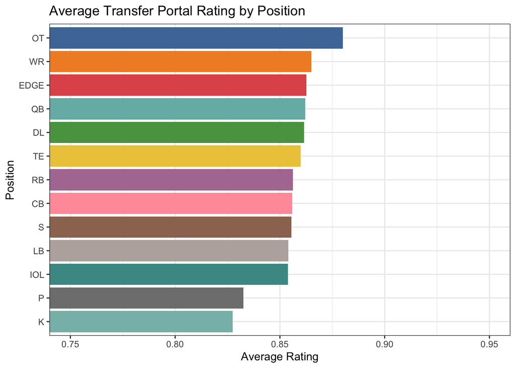

```r
# Use a manual color palette that supports more positions
cu_colors <- c(
  "OT"   = "#4E79A7", "WR"   = "#F28E2B", "EDGE" = "#E15759",
  "QB"   = "#76B7B2", "DL"   = "#59A14F", "TE"   = "#EDC948",
  "RB"   = "#B07AA1", "CB"   = "#FF9DA7", "S"    = "#9C755F",
  "LB"   = "#BAB0AC", "IOL"  = "#499894", "K"    = "#86BCB6"
)

transfer_stats %>%
  filter(!is.na(Rating)) %>%
  group_by(scoring_position) %>%
  summarise(avg_rating = mean(Rating, na.rm = TRUE), n = n()) %>%
  filter(n >= 5) %>%  # lowered threshold to capture more positions
  ggplot(aes(x = reorder(scoring_position, avg_rating), y = avg_rating, fill = scoring_position)) +
  geom_col(show.legend = FALSE) +
  coord_flip(ylim = c(0.75, 0.95)) +
  scale_fill_manual(values = cu_colors) +
  labs(title = "Average Transfer Portal Rating by Position",
       x = "Position", y = "Average Rating") +
  theme_bw()
```

We should also check stars vs performance. This justifies using our own scoring model rather than just using stars. I have to first check the availability of stats for each position

```r
# check stat availability by position group
transfer_stats %>%
  group_by(scoring_position) %>%
  summarise(
    # Offensive
    avg_passing_yds    = mean(passing_yds, na.rm = TRUE),
    avg_rushing_yds    = mean(rushing_yds, na.rm = TRUE),
    avg_receiving_yds  = mean(receiving_yds, na.rm = TRUE),
    # Defensive
    avg_sacks          = mean(defensive_sacks, na.rm = TRUE),
    avg_tackles        = mean(defensive_tot, na.rm = TRUE),
    avg_tfl            = mean(defensive_tfl, na.rm = TRUE),
    # Coverage
    avg_ints           = mean(interceptions_int, na.rm = TRUE),
    avg_pd             = mean(defensive_pd, na.rm = TRUE)
  ) %>%
  print()
```

```
## # A tibble: 14 × 9
##    scoring_position avg_passing_yds avg_rushing_yds avg_receiving_yds avg_sacks
##    <chr>                      <dbl>           <dbl>             <dbl>     <dbl>
##  1 CB                        NaN              17.5              21       0.0724
##  2 DL                        NaN             NaN                 2       0.771
##  3 EDGE                       84              14                23       1.49
##  4 IOL                       NaN              -0.75            NaN       0
##  5 K                         NaN              -1.5             NaN       0
##  6 LB                        NaN               1                 9.75    0.653
##  7 LS                        NaN             NaN                12       0
##  8 OT                        NaN              -3                 1.8     0
##  9 P                           8.33            8.5             NaN       0
## 10 QB                        914.            127.                4.65    0
## 11 RB                          7.67          368.               83.0     0
## 12 S                           0               8.5              16.5     0.142
## 13 TE                         28.5            13.5             148.      0
## 14 WR                         23.4            25.3             329.      0
## # ℹ 4 more variables: avg_tackles <dbl>, avg_tfl <dbl>, avg_ints <dbl>,
## #   avg_pd <dbl>
```

Looks like there is enough data to do a positional analysis. I need to exclude OT and IOL because there isn’t a blocking win rate metric here. We can maybe find it later, but for now we can focus on other positions

First, QB

```r
p_qb <- transfer_stats %>%
  filter(scoring_position == "QB", !is.na(Stars), Stars > 0) %>%
  select(Stars, passing_yds, passing_td, passing_pct) %>%
  pivot_longer(-Stars, names_to = "metric", values_to = "value") %>%
  filter(!is.na(value)) %>%
  mutate(metric = recode(metric,
    "passing_yds" = "Passing Yards",
    "passing_td"  = "Passing TDs",
    "passing_pct" = "Completion %"
  )) %>%
  ggplot(aes(x = as.factor(Stars), y = value)) +
  geom_boxplot(fill = "#4E79A7", alpha = 0.7, outlier.shape = 16, outlier.alpha = 0.4) +
  geom_jitter(width = 0.2, alpha = 0.3, color = "#E15759") +
  facet_wrap(~ metric, scales = "free_y") +
  labs(title = "QB: Star Rating vs Performance",
       subtitle = "Metrics: Completion %, Passing TDs, Passing Yards",
       x = "Star Rating", y = NULL) +
  theme_bw()
```

Now WR

```r
p_wr <- transfer_stats %>%
  filter(scoring_position == "WR", !is.na(Stars), Stars > 0) %>%
  select(Stars, receiving_rec, receiving_yds, receiving_td) %>%
  pivot_longer(-Stars, names_to = "metric", values_to = "value") %>%
  filter(!is.na(value)) %>%
  mutate(metric = recode(metric,
    "receiving_rec" = "Receptions",
    "receiving_yds" = "Receiving Yards",
    "receiving_td"  = "Receiving TDs"
  )) %>%
  ggplot(aes(x = as.factor(Stars), y = value)) +
  geom_boxplot(fill = "#F28E2B", alpha = 0.7, outlier.shape = 16, outlier.alpha = 0.4) +
  geom_jitter(width = 0.2, alpha = 0.3, color = "#E15759") +
  facet_wrap(~ metric, scales = "free_y") +
  labs(title = "WR: Star Rating vs Performance",
       subtitle = "Metrics: Receptions, Recieving Yds, Recieving TDs",
       x = "Star Rating", y = NULL) +
  theme_bw()
```

Now RB

```r
p_rb <- transfer_stats %>%
  filter(scoring_position == "RB", !is.na(Stars), Stars > 0) %>%
  select(Stars, rushing_yds, rushing_td, rushing_ypc) %>%
  pivot_longer(-Stars, names_to = "metric", values_to = "value") %>%
  filter(!is.na(value)) %>%
  mutate(metric = recode(metric,
    "rushing_yds" = "Rushing Yards",
    "rushing_td"  = "Rushing TDs",
    "rushing_ypc" = "Yards Per Carry"
  )) %>%
  ggplot(aes(x = as.factor(Stars), y = value)) +
  geom_boxplot(fill = "#EDC948", alpha = 0.7, outlier.shape = 16, outlier.alpha = 0.4) +
  geom_jitter(width = 0.2, alpha = 0.3, color = "#E15759") +
  facet_wrap(~ metric, scales = "free_y") +
  labs(title = "RB: Star Rating vs Performance",
       subtitle = "Metrics: Rushing YDs, Rushing TDs, YPC",
       x = "Star Rating", y = NULL) +
  theme_bw()
```

Now TEs

```r
p_te <- transfer_stats %>%
  filter(scoring_position == "TE", !is.na(Stars), Stars > 0) %>%
  select(Stars, receiving_rec, receiving_yds, receiving_td) %>%
  pivot_longer(-Stars, names_to = "metric", values_to = "value") %>%
  filter(!is.na(value)) %>%
  mutate(metric = recode(metric,
    "receiving_rec" = "Receptions",
    "receiving_yds" = "Receiving Yards",
    "receiving_td"  = "Receiving TDs"
  )) %>%
  ggplot(aes(x = as.factor(Stars), y = value)) +
  geom_boxplot(fill = "#59A14F", alpha = 0.7, outlier.shape = 16, outlier.alpha = 0.4) +
  geom_jitter(width = 0.2, alpha = 0.3, color = "#E15759") +
  facet_wrap(~ metric, scales = "free_y") +
  labs(title = "TE: Star Rating vs Performance",
       subtitle = "Metrics: Receptions, Recieving Yds, Recieving TDs",
       x = "Star Rating", y = NULL) +
  theme_bw()
```

Now edge rushers

```r
p_edge <- transfer_stats %>%
  filter(scoring_position == "EDGE", !is.na(Stars), Stars > 0) %>%
  select(Stars, defensive_sacks, defensive_tfl) %>%
  pivot_longer(-Stars, names_to = "metric", values_to = "value") %>%
  filter(!is.na(value)) %>%
  mutate(metric = recode(metric,
    "defensive_sacks" = "Sacks",
    "defensive_tfl"   = "Tackles for Loss"
  )) %>%
  ggplot(aes(x = as.factor(Stars), y = value)) +
  geom_boxplot(fill = "#E15759", alpha = 0.7, outlier.shape = 16, outlier.alpha = 0.4) +
  geom_jitter(width = 0.2, alpha = 0.3, color = "#4E79A7") +
  facet_wrap(~ metric, scales = "free_y") +
  labs(title = "EDGE: Star Rating vs Performance",
       subtitle = "Metrics: Sacks, TFL",
       x = "Star Rating", y = NULL) +
  theme_bw()
```

d-line

```r
p_dl <- transfer_stats %>%
  filter(scoring_position == "DL", !is.na(Stars), Stars > 0) %>%
  select(Stars, defensive_sacks, defensive_tfl) %>%
  pivot_longer(-Stars, names_to = "metric", values_to = "value") %>%
  filter(!is.na(value)) %>%
  mutate(metric = recode(metric,
    "defensive_sacks" = "Sacks",
    "defensive_tfl"   = "Tackles for Loss"
  )) %>%
  ggplot(aes(x = as.factor(Stars), y = value)) +
  geom_boxplot(fill = "#76B7B2", alpha = 0.7, outlier.shape = 16, outlier.alpha = 0.4) +
  geom_jitter(width = 0.2, alpha = 0.3, color = "#E15759") +
  facet_wrap(~ metric, scales = "free_y") +
  labs(title = "DL: Star Rating vs Performance",
       subtitle = "Metrics: Sacks, TFL",
       x = "Star Rating", y = NULL) +
  theme_minimal()
```

lbs

```r
p_lb <- transfer_stats %>%
  filter(scoring_position == "LB", !is.na(Stars), Stars > 0) %>%
  select(Stars, defensive_tot, defensive_tfl, defensive_sacks) %>%
  pivot_longer(-Stars, names_to = "metric", values_to = "value") %>%
  filter(!is.na(value)) %>%
  mutate(metric = recode(metric,
    "defensive_tot"   = "Total Tackles",
    "defensive_tfl"   = "Tackles for Loss",
    "defensive_sacks" = "Sacks"
  )) %>%
  ggplot(aes(x = as.factor(Stars), y = value)) +
  geom_boxplot(fill = "#BAB0AC", alpha = 0.7, outlier.shape = 16, outlier.alpha = 0.4) +
  geom_jitter(width = 0.2, alpha = 0.3, color = "#E15759") +
  facet_wrap(~ metric, scales = "free_y") +
  labs(title = "LB: Star Rating vs Performance",
       subtitle = "Metrics: Tackles, TFL, Sacks",
       x = "Star Rating", y = NULL) +
  theme_bw()
```

corners

```r
p_cb <- transfer_stats %>%
  filter(scoring_position == "CB", !is.na(Stars), Stars > 0) %>%
  select(Stars, interceptions_int, defensive_pd) %>%
  pivot_longer(-Stars, names_to = "metric", values_to = "value") %>%
  filter(!is.na(value)) %>%
  mutate(metric = recode(metric,
    "interceptions_int" = "Interceptions",
    "defensive_pd"      = "Passes Defended"
  )) %>%
  ggplot(aes(x = as.factor(Stars), y = value)) +
  geom_boxplot(fill = "#B07AA1", alpha = 0.7, outlier.shape = 16, outlier.alpha = 0.4) +
  geom_jitter(width = 0.2, alpha = 0.3, color = "#E15759") +
  facet_wrap(~ metric, scales = "free_y") +
  labs(title = "CB: Star Rating vs Performance",
       subtitle = "Metrics: Interceptions, Passes Defended",
       x = "Star Rating", y = NULL) +
  theme_minimal()
```

safetys

```r
p_s <- transfer_stats %>%
  filter(scoring_position == "S", !is.na(Stars), Stars > 0) %>%
  select(Stars, interceptions_int, defensive_pd) %>%
  pivot_longer(-Stars, names_to = "metric", values_to = "value") %>%
  filter(!is.na(value)) %>%
  mutate(metric = recode(metric,
    "interceptions_int" = "Interceptions",
    "defensive_pd"      = "Passes Defended"
  )) %>%
  ggplot(aes(x = as.factor(Stars), y = value)) +
  geom_boxplot(fill = "#EDC948", alpha = 0.7, outlier.shape = 16, outlier.alpha = 0.4) +
  geom_jitter(width = 0.2, alpha = 0.3, color = "#E15759") +
  facet_wrap(~ metric, scales = "free_y") +
  labs(title = "S: Star Rating vs Performance",
       subtitle = "Metrics: Interceptions, Passes Defended",
       x = "Star Rating", y = NULL) +
  theme_minimal()
```

Now print all of them

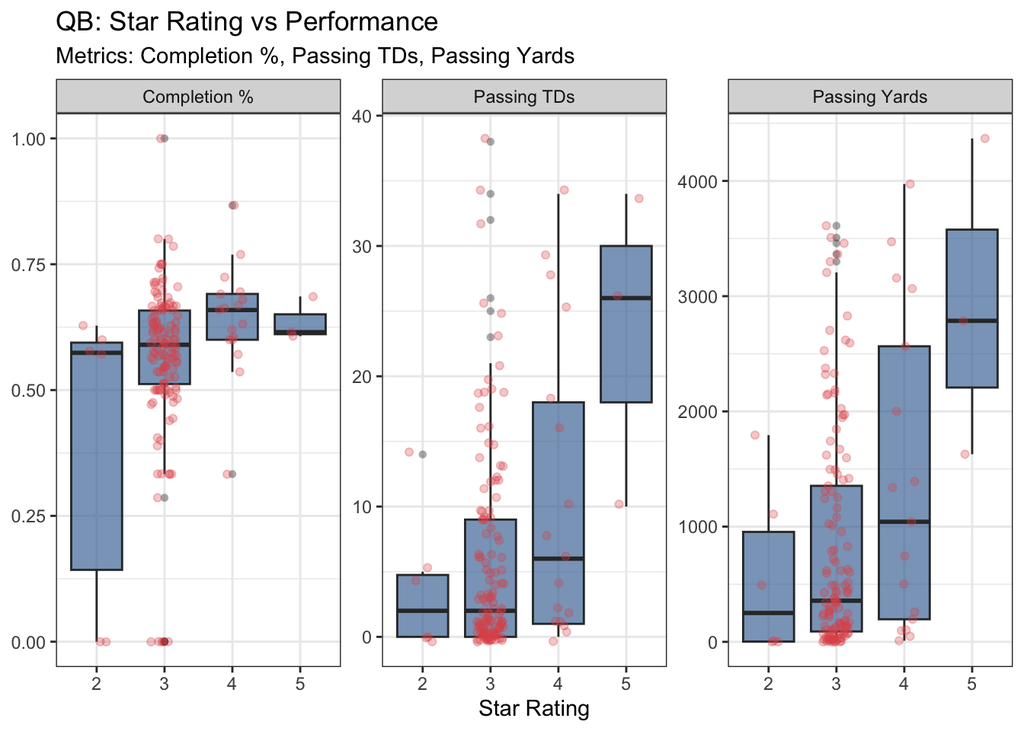

```r
print(p_qb)
```

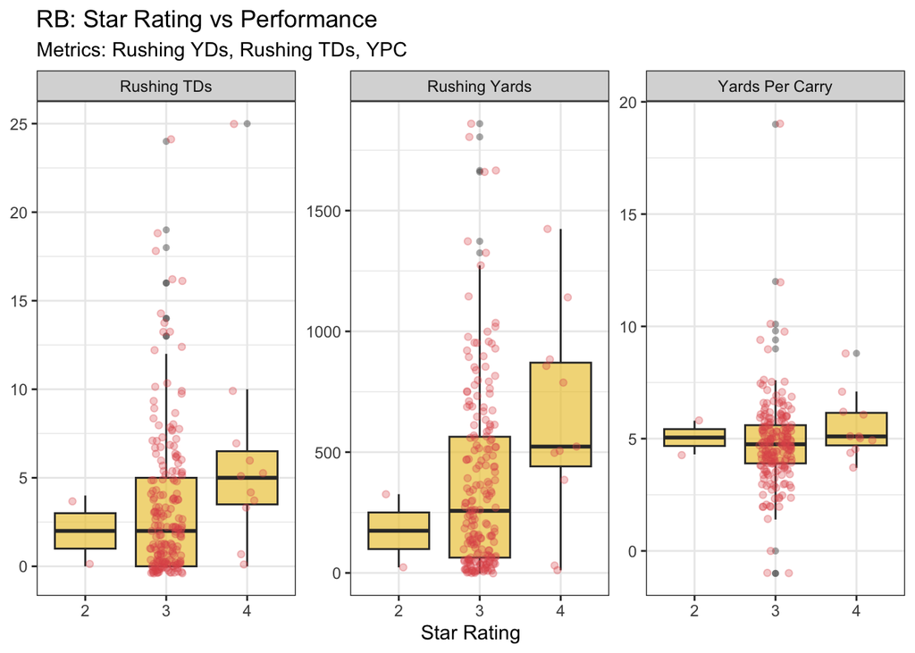

```r
print(p_rb)
```

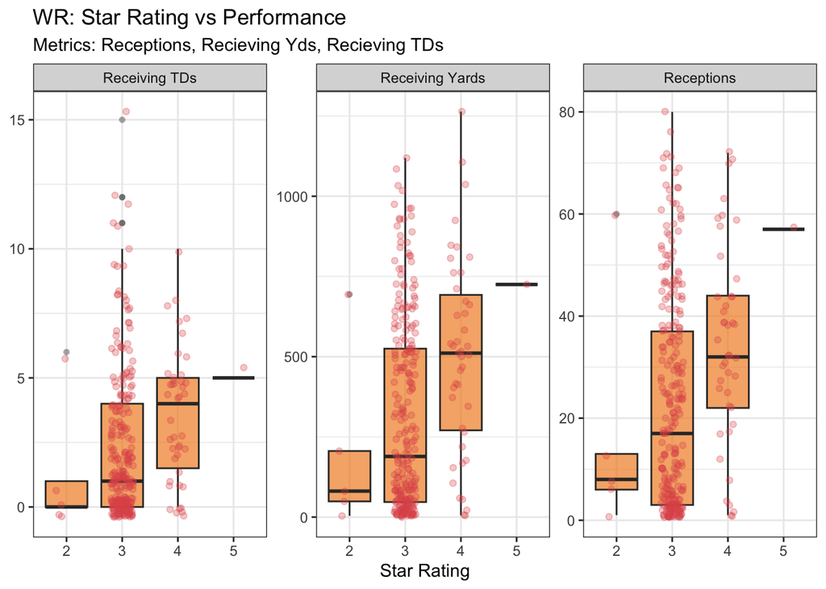

```r
print(p_wr)
```

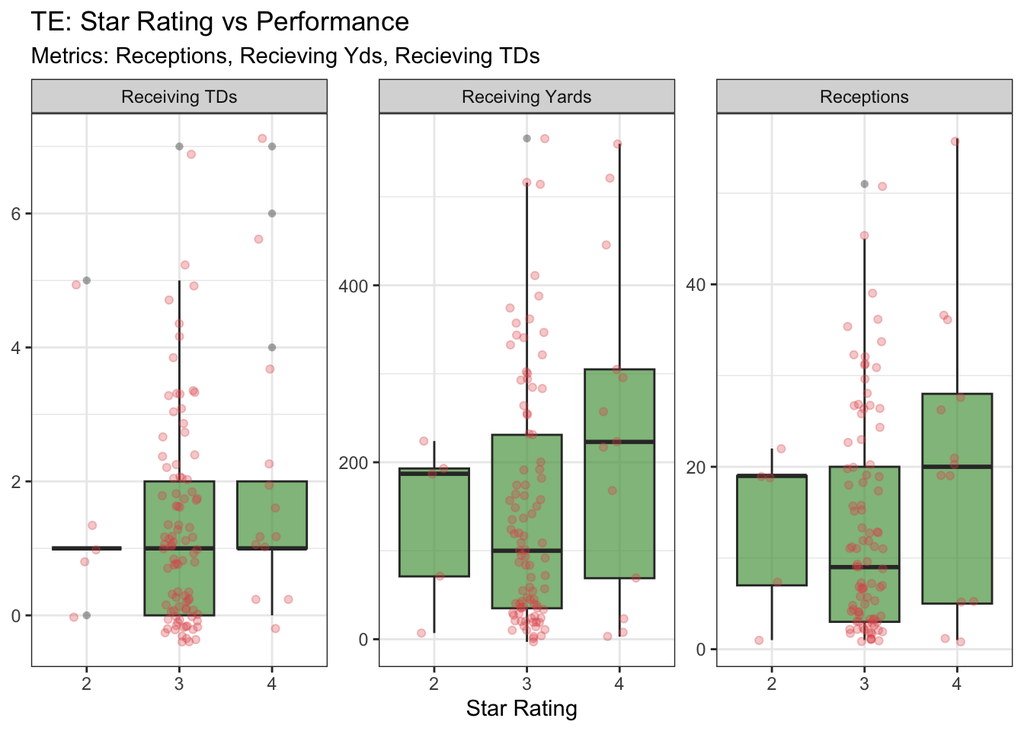

```r
print(p_te)
```

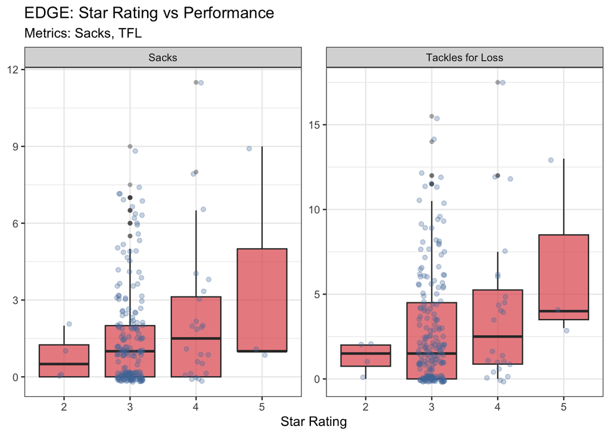

```r
print(p_edge)
```

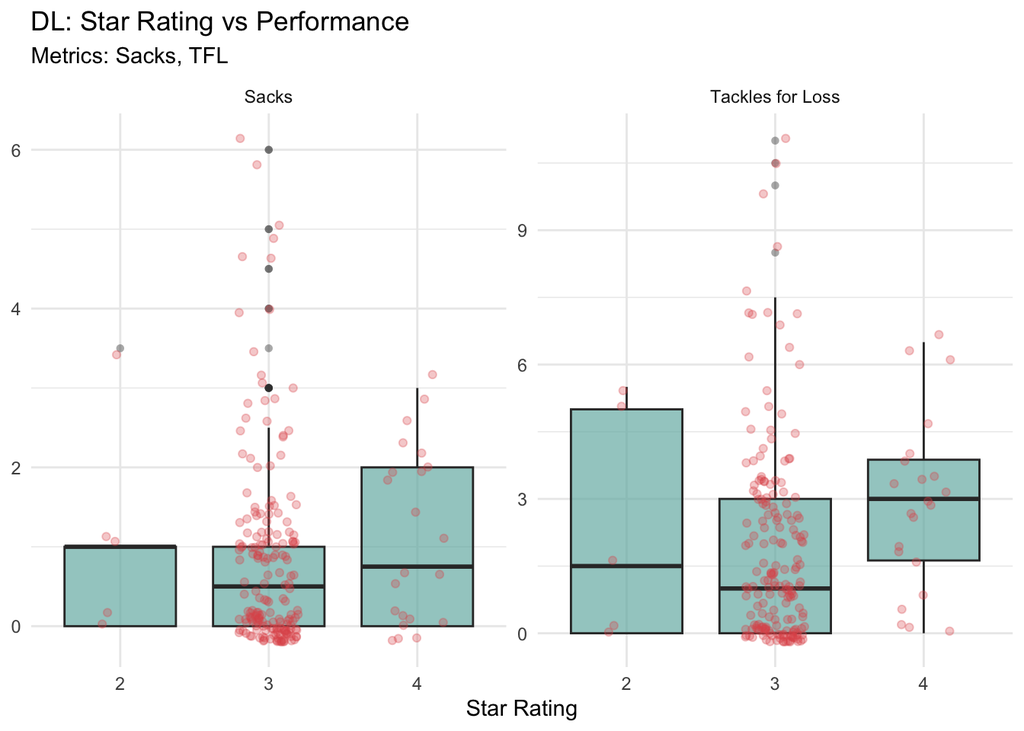

```r
print(p_dl)
```

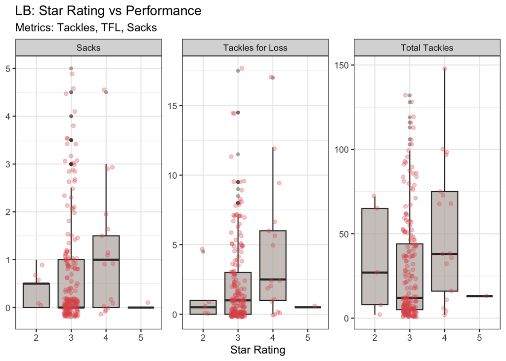

```r
print(p_lb)
```

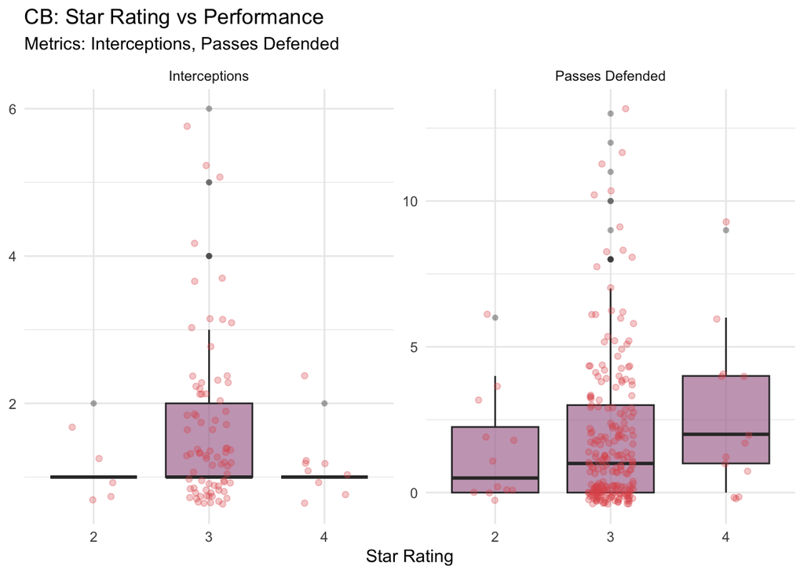

```r
print(p_cb)
```

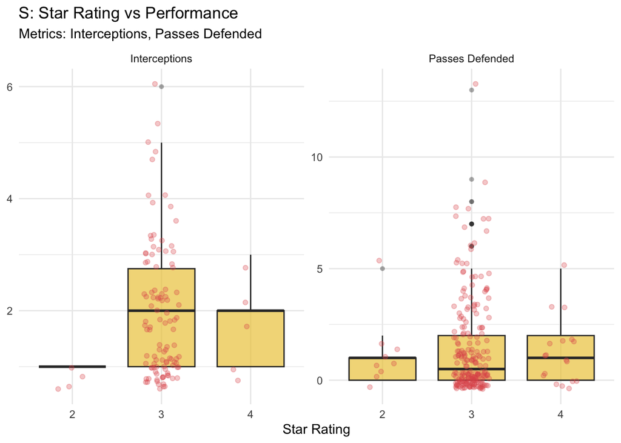

```r
print(p_s)
```

NOTE: This is just exploratory, this does not take into account strength of schedule

QB: Passing TDs and Passing Yards show a pretty clear upward trend with star rating, especially from 3 to 4 to 5 stars. Higher rated QBs are putting up more volume stats. This makes sense, as better QBs get more starts and throw more. For completion %, the trend is weaker. A 3-star QB has nearly identical completion % to a 4 or 5-star QB. The boxes overlap heavily. This suggests that star rating doesn’t predict accuracy and completion % well at all.

RB: Rushing Yards and Rushing TDs show a modest upward trend from 3 to 4 stars, but again this is confounded by playing time. A 4-star RB is more likely to be a featured back getting 20 carries a game vs a 3-star backup. Yards Per Carry is the most interesting panel. The median YPC is pretty much identical across all star ratings (all hovering around 5.0 yards per carry). The boxes are almost perfectly overlapping. This means that once a RB actually gets carries, a 2-star back is just as efficient as a 4-star back. This heavily justifies a performance based model.

WR: Similar to QB, volume stats trend upward with star rating. However the boxes overlap at 3 and 4 stars, meaning there are plenty of 3-star WRs outperforming 4-star WRs. The 5-star sample is tiny so that data point isn’t very meaningful.

DL: The 2-star DLs have a surprisingly high TFL median. Could be a small sample size. The 3 to 4 star trend is modest at best. Star rating is a poor predictor of DL production.

LB: Sacks and TFL show a modest upward trend from 3 to 4 stars, which makes intuitive sense, as higher rated LBs are more likely to be used as pass rushers in their scheme. However the boxes overlap heavily and the variance within each tier is huge, so the signal is weak. Total Tackles is the most interesting panel, and it’s counterintuitive. The 2-star LBs have a surprisingly high tackle median, and the 3-star group has the widest variance of any position/metric combination. The 5-star group is a flat line near zero, which reflects a sample size problem. There are probably only 1-2 five star LBs in the portal and they may not have played much. LB is the most scheme dependent position on the field. A LB’s tackle total is mostly determined by whether they’re a box linebacker or a coverage linebacker in their scheme, and star rating captures none of that. A 3-star box LB racking up 80 tackles is not necessarily better than a 4-star coverage LB with 30 tackles.

CB: Very weak relationship. Interceptions show almost no trend across star ratings, and passes defended only modestly improves from 3 to 4 stars. CB is tough, as it is influenced by scheme and how often quarterbacks throw their way, so star rating misses a lot here.

```r
transfer_stats %>%
  count(conference) %>%
  arrange(desc(n)) %>%
  head(30)
```

```
##           conference   n
## 1             Big 12 265
## 2                SEC 256
## 3            Big Ten 248
## 4                ACC 239
## 5           Sun Belt 227
## 6  American Athletic 212
## 7       Mid-American 167
## 8     Conference USA 133
## 9      Mountain West 110
## 10           Big Sky  67
## 11               CAA  64
## 12          Southern  53
## 13            Pac-12  49
## 14               UAC  42
## 15     Big South-OVC  41
## 16         Southland  40
## 17           Patriot  37
## 18              MVFC  36
## 19  FBS Independents  35
## 20              SWAC  35
## 21               Ivy  25
## 22              MEAC  20
## 23               NEC  20
## 24           Pioneer  16
## 25  FCS Independents   3
## 26              SIAC   1
```

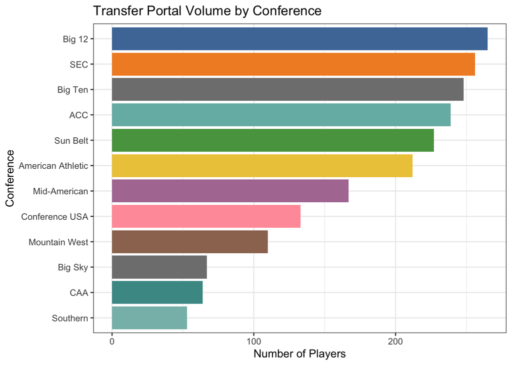

```r
conference_colors <- c(
  "Big 12"   = "#4E79A7", "SEC"   = "#F28E2B", "Big 10" = "#E15759",
  "ACC"   = "#76B7B2", "Sun Belt"   = "#59A14F", "American Athletic"   = "#EDC948",
  "Mid-American"   = "#B07AA1", "Conference USA"   = "#FF9DA7", "Mountain West"    = "#9C755F",
  "Big Ski"   = "#BAB0AC", "CAA"  = "#499894", "Southern"    = "#86BCB6"
)


transfer_stats %>%
  count(conference) %>%
  arrange(desc(n)) %>%
  head(12) %>%
  ggplot(aes(x = reorder(conference, n), y = n, fill = conference)) +
  geom_col(show.legend = FALSE) +
  coord_flip() +
  scale_fill_manual(values = conference_colors) +
  labs(title = "Transfer Portal Volume by Conference",
       x = "Conference", y = "Number of Players") +
  theme_bw()
```

```r
ls("package:cfbfastR") %>%
  as_tibble() %>%
  filter(str_detect(value, "rating|Rating|sos|SOS|sp|SP|fpi|FPI"))
```

```
## # A tibble: 13 × 1
##    value
##    <chr>
##  1 cfbd_ratings_elo
##  2 cfbd_ratings_fpi
##  3 cfbd_ratings_sp
##  4 cfbd_ratings_sp_conference
##  5 cfbd_ratings_srs
##  6 espn_cfb_calendar
##  7 espn_cfb_pbp
##  8 espn_cfb_player_stats
##  9 espn_cfb_schedule
## 10 espn_cfb_scoreboard
## 11 espn_cfb_team_stats
## 12 espn_metrics_wp
## 13 espn_ratings_fpi
```

```r
sp <- cfbd_ratings_sp(year = 2025)
names(sp)
```

```
##  [1] "year"                      "team"
##  [3] "conference"                "rating"
##  [5] "ranking"                   "second_order_wins"
##  [7] "sos"                       "offense_ranking"
##  [9] "offense_rating"            "offense_success"
## [11] "offense_explosiveness"     "offense_rushing"
## [13] "offense_passing"           "offense_standard_downs"
## [15] "offense_passing_downs"     "offense_run_rate"
## [17] "offense_pace"              "defense_ranking"
## [19] "defense_rating"            "defense_success"
## [21] "defense_explosiveness"     "defense_rushing"
## [23] "defense_passing"           "defense_standard_downs"
## [25] "defense_passing_downs"     "defense_havoc_total"
## [27] "defense_havoc_front_seven" "defense_havoc_db"
## [29] "special_teams_rating"
```

```r
transfer_stats <- transfer_stats %>%
  left_join(
    sp %>%
      select(team, sos, rating, ranking),
    by = c("Origin" = "team")
  ) %>%
  rename(
    origin_sos     = sos,
    origin_sp_rating  = rating,
    origin_sp_ranking = ranking
  )
```

```r
# Check which columns are populated in sp
sp %>%
  summarise(across(everything(), ~ sum(!is.na(.)))) %>%
  pivot_longer(everything(), names_to = "column", values_to = "non_na_count") %>%
  arrange(desc(non_na_count))
```

```
## # A tibble: 29 × 2
##    column               non_na_count
##    <chr>                       <int>
##  1 year                          137
##  2 team                          137
##  3 rating                        137
##  4 offense_rating                137
##  5 defense_rating                137
##  6 special_teams_rating          137
##  7 conference                    136
##  8 ranking                       136
##  9 offense_ranking               136
## 10 defense_ranking               136
## # ℹ 19 more rows
```

Unfortunately, SOS is not populated. However, we can use rating, offense_rating, and defense_rating.

Instead of SOS, using the SP+ rating of the origin team as a proxy for competition level. A player putting up stats on a top 25 SP+ team faced better competition than someone on a bottom 25 team.

Now the logic for scoring is:

Offensive players: Weight stats by their team’s origin_sp_defense_rating of opponents faced Defensive players: Weight stats by their team’s origin_sp_offense_rating of opponents faced

```r
#join team rating to transfer_stats
transfer_stats <- transfer_stats %>%
  left_join(
    sp %>%
      select(team, rating, ranking, offense_rating, defense_rating),
    by = c("Origin" = "team")
  ) %>%
  rename(
    origin_sp_offense_rating  = offense_rating,
    origin_sp_defense_rating  = defense_rating
  )

# Check how many NAs
sum(is.na(transfer_stats$origin_sp_rating))
```

```
## [1] 500
```

```r
# Which origin teams didn't match SP+
transfer_stats %>%
  filter(is.na(origin_sp_rating)) %>%
  count(Origin) %>%
  arrange(desc(n)) %>%
  head(30)
```

```
##                      Origin  n
## 1          Sacramento State 16
## 2          Western Carolina 13
## 3               Weber State 12
## 4              Gardner-Webb 11
## 5                Holy Cross  9
## 6                    Mercer  9
## 7              West Georgia  9
## 8          Eastern Kentucky  8
## 9                      Elon  8
## 10              Florida A&M  7
## 11           Illinois State  7
## 12                  McNeese  7
## 13        Northern Colorado  7
## 14                Villanova  7
```

[output cut: 16 more lines]

```r
#give default rating for FCS/unrated teams
transfer_stats <- transfer_stats %>%
  mutate(
    origin_sp_rating         = replace_na(origin_sp_rating, -20),
    origin_sp_ranking        = replace_na(origin_sp_ranking, 150),
    origin_sp_offense_rating = replace_na(origin_sp_offense_rating, -10),
    origin_sp_defense_rating = replace_na(origin_sp_defense_rating, 39)
  )
```

```r
sum(is.na(transfer_stats$origin_sp_rating))
```

```
## [1] 0
```

```r
ls("package:cfbfastR") %>%
  as_tibble() %>%
  filter(str_detect(value, "schedule|Schedule|games|Games"))
```

```
## # A tibble: 4 × 1
##   value
##   <chr>
## 1 cfbd_metrics_ppa_games
## 2 cfbd_metrics_ppa_players_games
## 3 espn_cfb_schedule
## 4 load_cfb_schedules
```

```r
schedule <- espn_cfb_schedule(year = 2025)
```

```r
names(schedule)
```

```
##  [1] "matchup"                    "matchup_short"
##  [3] "season"                     "type"
##  [5] "slug"                       "game_id"
##  [7] "game_uid"                   "game_date"
##  [9] "attendance"                 "date_valid"
## [11] "play_by_play_available"     "home_team_name"
## [13] "home_team_logo"             "home_team_abb"
## [15] "home_team_id"               "home_team_location"
## [17] "home_team_full"             "home_team_color"
## [19] "home_score"                 "home_win"
## [21] "home_record"                "away_team_name"
## [23] "away_team_logo"             "away_team_abb"
## [25] "away_team_id"               "away_team_location"
## [27] "away_team_full"             "away_team_color"
## [29] "away_score"                 "away_win"
## [31] "away_record"                "status_name"
## [33] "broadcast_market"           "broadcast_name"
## [35] "passing_leader_yards"       "passing_leader_stat"
## [37] "passing_leader_name"        "passing_leader_shortname"
## [39] "passing_leader_headshot"    "passing_leader_team_id"
## [41] "passing_leader_pos"         "rushing_leader_yards"
## [43] "rushing_leader_stat"        "rushing_leader_name"
## [45] "rushing_leader_shortname"   "rushing_leader_headshot"
## [47] "rushing_leader_team_id"     "rushing_leader_pos"
## [49] "receiving_leader_yards"     "receiving_leader_stat"
## [51] "receiving_leader_name"      "receiving_leader_shortname"
## [53] "receiving_leader_headshot"  "receiving_leader_team_id"
## [55] "receiving_leader_pos"       "start_date"
## [57] "broadcast"                  "game_date_time"
## [59] "highlights"
```

```r
fbs_teams <- sp %>%
  distinct(team)

#reshape schedule so every row is team + opponent
home_games <- schedule %>%
  select(home_team_location, away_team_location) %>%
  rename(team = home_team_location, opponent = away_team_location)

away_games <- schedule %>%
  select(away_team_location, home_team_location) %>%
  rename(team = away_team_location, opponent = home_team_location)

all_games <- bind_rows(home_games, away_games) %>%
  filter(team     %in% fbs_teams$team,   # both teams must be FBS
         opponent %in% fbs_teams$team)
```

```r
#join opponent SP+ rating to each game

all_games <- all_games %>%
  left_join(
    sp %>% select(team, offense_rating, defense_rating),
    by = c("opponent" = "team")
  ) %>%
  rename(
    opponent_offense_sp = offense_rating,
    opponent_defense_sp = defense_rating
  )
```

```r
#calculate average opponent sp+ rating per team
avg_opponent_sp <- all_games %>%
  group_by(team) %>%
  summarise(
    avg_opponent_offense_sp = mean(opponent_offense_sp, na.rm = TRUE),
    avg_opponent_defense_sp = mean(opponent_defense_sp, na.rm = TRUE),
    n_fbs_games             = n(),
    .groups = "drop"
  ) %>%
  mutate(
    # LOWER opponent defense SP+ = better defense = higher multiplier (flip it)
    sos_off_multiplier = 1 - percent_rank(avg_opponent_defense_sp),
    # HIGHER opponent offense SP+ = better offense = higher multiplier
    sos_def_multiplier = percent_rank(avg_opponent_offense_sp)
  )
```

```r
#re-join to transfer_stats
transfer_stats <- transfer_stats %>%
  select(-any_of(c("avg_opponent_offense_sp", "avg_opponent_defense_sp",
                   "n_fbs_games", "sos_off_multiplier",
                   "sos_def_multiplier"))) %>%
  left_join(avg_opponent_sp, by = c("Origin" = "team")) %>%
  mutate(
    sos_off_multiplier = replace_na(sos_off_multiplier, 0.5),
    sos_def_multiplier = replace_na(sos_def_multiplier, 0.5)
  )

#percent_rank converts numbers into a percentile between 0 and 1 based on their rank relative to other values in the column
```

```r
#verify
#see the full distribution
avg_opponent_sp %>%
  arrange(avg_opponent_defense_sp) %>%
  select(team, avg_opponent_defense_sp, sos_off_multiplier) %>%
  print(n = 30)
```

```
## # A tibble: 136 × 3
##    team              avg_opponent_defense_sp sos_off_multiplier
##    <chr>                               <dbl>              <dbl>
##  1 Wisconsin                            18.5              1
##  2 Alabama                              19.2              0.993
##  3 Purdue                               19.5              0.985
##  4 Rutgers                              19.6              0.978
##  5 UCLA                                 20.2              0.970
##  6 Florida                              20.2              0.963
##  7 Oregon                               20.2              0.956
##  8 Ohio State                           20.4              0.948
##  9 South Carolina                       20.6              0.941
## 10 Oklahoma                             20.7              0.933
## 11 Kentucky                             20.9              0.926
## 12 Arkansas                             21.3              0.919
```

[output cut: 19 more lines]

```r
#check the range
summary(avg_opponent_sp$avg_opponent_defense_sp)
```

```
##    Min. 1st Qu.  Median    Mean 3rd Qu.    Max.
##   18.51   23.24   25.88   26.26   29.60   33.26
```

```r
#check what's available for each position
transfer_stats %>%
  filter(scoring_position == "QB") %>%
  summarise(
    n_passing_int = sum(!is.na(passing_int) & passing_int > 0),
    n_passing_att = sum(!is.na(passing_att) & passing_att > 0)
  )
```

```
##   n_passing_int n_passing_att
## 1           116           168
```

```r
transfer_stats %>%
  filter(scoring_position == "RB") %>%
  summarise(
    n_rushing_car = sum(!is.na(rushing_car) & rushing_car > 0)  # attempts/carries
  )
```

```
##   n_rushing_car
## 1           228
```

```r
transfer_stats %>%
  filter(scoring_position %in% c("WR", "TE")) %>%
  summarise(
    n_receiving_rec = sum(!is.na(receiving_rec) & receiving_rec > 0),
    n_receiving_ypr = sum(!is.na(receiving_ypr) & receiving_ypr > 0)
  )
```

```
##   n_receiving_rec n_receiving_ypr
## 1             489             486
```

```r
transfer_stats <- transfer_stats %>%
  mutate(
    sos_off_multiplier = case_when(
      is.na(avg_opponent_defense_sp) ~ 0.2,  # fcs penalty
      TRUE                           ~ sos_off_multiplier
    ),
    sos_def_multiplier = case_when(
      is.na(avg_opponent_defense_sp) ~ 0.2,
      TRUE                           ~ sos_def_multiplier
    )
  )
```

```r
transfer_stats <- transfer_stats %>%
  mutate(conf_bonus = case_when(
    conference %in%
      c("SEC", "Big Ten",
        "Big 12", "ACC")        ~ 1.03,

    conference %in%
      c("Sun Belt", "American Athletic",
        "Mid-American", "Conference USA",
        "Mountain West")        ~ 1.00,

    conference %in%
      c("CAA", "Big Sky", "Southland",
        "MVFC", "Ivy", "Patriot",
        "Pioneer", "SWAC", "MEAC",
        "NEC", "Southern", "UAC",
        "Big South-OVC",
        "FCS Independents", "SIAC") ~ 0.8,

    TRUE                                      ~ 0.80
  ))
```

# QB MODEL:

```r
qb_scores <- transfer_stats %>%
  filter(scoring_position == "QB",
         passing_att >= 200) %>%
  mutate(
    int_rate = passing_int / passing_att,

    #SOS adjust volume stats
    passing_yds_adj = passing_yds * sos_off_multiplier,
    passing_td_adj  = passing_td  * sos_off_multiplier,

    #percentile rank within position
    pct_passing_yds = percent_rank(passing_yds_adj),
    pct_passing_td  = percent_rank(passing_td_adj),
    pct_passing_pct = percent_rank(passing_pct),
    pct_passing_ypa = percent_rank(passing_ypa),
    pct_int_rate    = 1 - percent_rank(int_rate),

    #composite score with weights
    composite_score = ((pct_passing_ypa * 0.30) +
                       (pct_passing_td  * 0.20) +
                       (pct_passing_yds * 0.20) +
                       (pct_passing_pct * 0.15) +
                       (pct_int_rate    * 0.15)) * 100 * conf_bonus
  ) %>%
  select(full_name, Origin, Destination, conference, Stars, Eligibility,
         passing_yds, passing_td, passing_pct, passing_ypa, int_rate,
         sos_off_multiplier, conf_bonus, composite_score) %>%
  arrange(desc(composite_score))
```

```r
cat("TOP 10 QBs\n"); qb_scores %>%
  head(10) %>%
  print()
```

```
## TOP 10 QBs
```

```
##              full_name           Origin    Destination        conference Stars
## 1  Demond Williams Jr.       Washington                          Big Ten     4
## 2        Darian Mensah             Duke          Miami               ACC     4
## 3      Drew Mestemaker      North Texas Oklahoma State American Athletic     5
## 4         Dylan Raiola         Nebraska         Oregon           Big Ten     4
## 5       Brendan Sorsby       Cincinnati     Texas Tech            Big 12     5
## 6          Byrum Brown    South Florida         Auburn American Athletic     4
## 7          Josh Hoover              TCU        Indiana            Big 12     4
## 8    Anthony Colandrea             UNLV       Nebraska     Mountain West     3
## 9        Taron Dickens Western Carolina North Carolina          Southern     3
## 10      Dylan Lonergan   Boston College        Rutgers               ACC     3
##    Eligibility passing_yds passing_td passing_pct passing_ypa    int_rate
## 1    Immediate        3065         25       0.695         8.7 0.022598870
## 2    Immediate        3973         34       0.668         7.9 0.012000000
## 3    Immediate        4369         34       0.686         9.4 0.019354839
```

[output cut: 18 more lines]

# WR MODEL

```r
wr_scores <- transfer_stats %>%
  filter(scoring_position == "WR",
         receiving_rec >= 20) %>%
   mutate(
    # SOS adjust volume stats
    receiving_yds_adj = receiving_yds * sos_off_multiplier,
    receiving_rec_adj = receiving_rec * sos_off_multiplier,
    receiving_td_adj  = receiving_td  * sos_off_multiplier,

    # Percentile rank within position
    pct_receiving_yds = percent_rank(receiving_yds_adj),
    pct_receiving_rec = percent_rank(receiving_rec_adj),
    pct_receiving_ypr = percent_rank(receiving_ypr),
    pct_receiving_td  = percent_rank(receiving_td_adj),

    # Composite score with weights
    composite_score = ((pct_receiving_yds * 0.35) +
                       (pct_receiving_rec * 0.30) +
                       (pct_receiving_ypr * 0.15) +
                       (pct_receiving_td  * 0.20)) * 100 * conf_bonus
  ) %>%
  select(full_name, Origin, Destination, conference, Stars, Eligibility,
         receiving_yds, receiving_rec, receiving_ypr, receiving_td,
         sos_off_multiplier, conf_bonus, composite_score) %>%
  arrange(desc(composite_score))
```

```r
cat("TOP 10 WRs\n"); wr_scores %>%
  head(10) %>%
  print()
```

```
## TOP 10 WRs
```

```
##             full_name         Origin    Destination conference Stars
## 1      Tre Richardson     Vanderbilt     Louisville        SEC     4
## 2      Omarion Miller       Colorado  Arizona State     Big 12     4
## 3      Cooper Barkate           Duke          Miami        ACC     4
## 4          Ian Strong        Rutgers     California    Big Ten     4
## 5    Terrell Anderson       NC State            USC        ACC     4
## 6         Jayce Brown   Kansas State            LSU     Big 12     4
## 7        Nitro Tuggle         Purdue South Carolina    Big Ten     3
## 8  Parker Livingstone          Texas       Oklahoma        SEC     4
## 9      Que'Sean Brown           Duke  Virginia Tech        ACC     4
## 10         Nick Marsh Michigan State        Indiana    Big Ten     4
##    Eligibility receiving_yds receiving_rec receiving_ypr receiving_td
## 1    Immediate           810            47          17.2            7
## 2    Immediate           807            44          18.3            8
## 3    Immediate          1106            72          15.4            7
```

[output cut: 18 more lines]

# RB MODEL

```r
rb_scores <- transfer_stats %>%
  filter(scoring_position == "RB",
         rushing_car >= 75) %>%
  mutate(
    # SOS adjust volume stats
    rushing_yds_adj = rushing_yds * sos_off_multiplier,
    rushing_td_adj  = rushing_td  * sos_off_multiplier,
    rushing_car_adj = rushing_car * sos_off_multiplier,

    # Percentile rank within position
    pct_rushing_ypc  = percent_rank(rushing_ypc),
    pct_rushing_yds  = percent_rank(rushing_yds_adj),
    pct_rushing_car  = percent_rank(rushing_car_adj),
    pct_rushing_td   = percent_rank(rushing_td_adj),
    pct_rushing_long = percent_rank(rushing_long),

    # Composite score with weights
    composite_score = ((pct_rushing_ypc  * 0.30) +
                       (pct_rushing_yds  * 0.25) +
                       (pct_rushing_car  * 0.25) +
                       (pct_rushing_td   * 0.15) +
                       (pct_rushing_long * 0.05)) * 100 * conf_bonus
  ) %>%
  select(full_name, Origin, Destination, conference, Stars, Eligibility,
         rushing_yds, rushing_td, rushing_ypc, rushing_car, rushing_long,
         sos_off_multiplier, conf_bonus, composite_score) %>%
  arrange(desc(composite_score))
```

```r
cat("TOP 10 RBs\n"); rb_scores %>%
  head(10) %>%
  print()
```

```
## TOP 10 RBs
```

```
##            full_name         Origin    Destination        conference Stars
## 1     Justice Haynes       Michigan   Georgia Tech           Big Ten     4
## 2        Isaac Brown     Louisville                              ACC     4
## 3       Raleek Brown  Arizona State          Texas            Big 12     4
## 4  Bryson Washington         Baylor         Auburn            Big 12     4
## 5      Turbo Richard Boston College        Indiana               ACC     3
## 6      Carson Hansen     Iowa State     Penn State            Big 12     3
## 7      Caleb Hawkins    North Texas Oklahoma State American Athletic     4
## 8      Dante Dowdell       Kentucky        Georgia               SEC     3
## 9         Evan Pryor     Cincinnati        Florida            Big 12     3
## 10      Abu Sama III     Iowa State      Wisconsin            Big 12     3
##    Eligibility rushing_yds rushing_td rushing_ypc rushing_car rushing_long
## 1    Immediate         857         10         7.1         121           75
## 2    Immediate         884          7         8.8         101           78
## 3    Immediate        1141          4         6.1         186           88
```

[output cut: 18 more lines]

# TE MODEL

```r
te_scores <- transfer_stats %>%
  filter(scoring_position == "TE",
         receiving_rec >= 10) %>%
  mutate(
    #SOS adjust volume stats
    receiving_yds_adj = receiving_yds * sos_off_multiplier,
    receiving_rec_adj = receiving_rec * sos_off_multiplier,
    receiving_td_adj  = receiving_td  * sos_off_multiplier,

    #percentile rank within position
    pct_receiving_td  = percent_rank(receiving_td_adj),
    pct_receiving_yds = percent_rank(receiving_yds_adj),
    pct_receiving_rec = percent_rank(receiving_rec_adj),
    pct_receiving_ypr = percent_rank(receiving_ypr),

    #composite score with weights
    composite_score = ((pct_receiving_td  * 0.30) +
                       (pct_receiving_yds * 0.30) +
                       (pct_receiving_rec * 0.25) +
                       (pct_receiving_ypr * 0.15)) * 100 * conf_bonus
  ) %>%
  select(full_name, Origin, Destination, conference, Stars, Eligibility,
         receiving_yds, receiving_rec, receiving_ypr, receiving_td,
         sos_off_multiplier, conf_bonus, composite_score) %>%
  arrange(desc(composite_score))
```

```r
cat("TOP 10 TEs\n"); te_scores %>%
  head(10) %>%
  print()
```

```
## TOP 10 TEs
```

```
##           full_name         Origin Destination    conference Stars Eligibility
## 1  Benjamin Brahmer     Iowa State  Penn State        Big 12     4   Immediate
## 2       Rocky Beers Colorado State    Oklahoma Mountain West     3   Immediate
## 3   Michael Masunas Michigan State       Texas       Big Ten     3   Immediate
## 4     Hayden Hansen        Florida    Oklahoma           SEC     3   Immediate
## 5    Hunter Welcing   Northwestern  Ohio State       Big Ten     4   Immediate
## 6     Dorian Thomas     New Mexico  California Mountain West     4   Immediate
## 7         Cole Rusk       Illinois     Arizona       Big Ten     4   Immediate
## 8      Walker Lyons            USC         BYU       Big Ten     4   Immediate
## 9    Malachi Thomas     Pittsburgh         LSU           ACC     3   Immediate
## 10  Tony Livingston        Florida      Baylor           SEC     3   Immediate
##    receiving_yds receiving_rec receiving_ypr receiving_td sos_off_multiplier
## 1            446            37          12.1            6          0.5703704
## 2            388            31          12.5            7          0.5851852
## 3            232            19          12.2            3          0.9037037
```

[output cut: 18 more lines]